# Measurement Error

Sy Doan

August 4, 2016

A quick primer on the effects of measurement error in regression models. This primer relies heavily on Dale Ballou’s lecture notes and Richard William’s posted [notes](https://www3.nd.edu/~rwilliam/stats2/l21.pdf), which you should read if you just want a better version of what I typed here.

# Defining measurement error

Assume $X$ is some variable of interest and is measured with error, denoted $\epsilon$. This error is additive, meaning it can be represented like this:

$$X = X_t + \epsilon$$

where $X_t$ is the “true” $X$, measured without error. Error comes in two forms:

1. Systematic measurement error, where there is a pattern to the error (e.g., all respondents systematically under-reporting the amount of marijuana they smoke, the ends of a test scale being more prone to measurement error than values in the middle of a test scale). How to address this error depends on the nature of its patterns.
2. Random (or “classical”) measurement error, where the error occurs at random. More specifically, it is error with a mean of zero, constant variance, and is unrelated to either values of X (i.e., $cov(X,\epsilon)=0$) or any other variable included in the model.

The focus of this guide will be on random measurement error.

# Issues created by random measurement error

The effects of random measurement error on a regression model will depend on whether measurement error affects the dependent or independent variables. Broadly speaking:

1. Random measurement error in the dependent variable will not result in biased coefficients but will result in inflated standard errors.
2. Random measurement error in the independent variable will result in `attenuation bias`, or bias that shifts the coefficient closer to 0 than it should be.

It may be surprising that random error that is not correlated with the independent variable and is mean zero will cause bias on any estimated coefficient. The logic behind why this is, and relatedly, why measurement error in the dependent variable does not result in biased coefficients, can be motivated both graphically and mathematically.

# A graphical representation of random measurement error

Below is a set of plots that illustrate the effects of random measurement error on a simple model $Y = \beta_0 + \beta_1X$ where the true value of $\beta_1 = 1$. To set this up, we simply make both our X and Y variables all integers from 1-100.

```r
x <- seq(1,100, 1)
y <- seq(1,100, 1)
```

Clearly, if we were to run a regression, the slope would be 1 and run perfectly through all the points. The first plot (“1. No Measurement Error”) depicts this. The bolded number within the plot is the value of $\beta_1$. The red line is the linear fit line where $\beta_1 = 1$ and is included in all plots for reference.

```r
error <- rnorm(100,0,1)*30
x_error <- x+error
y_error <- y+error
```

We then run the same bivariate regression, but in one model using the Y measured with error (“2. Random Error in Y”) and the other the X measured with error (“3. Random Error in X”). The blue lines are the best fit lines when estimated using the “with error” variables and the red line still represents the true best fit line.

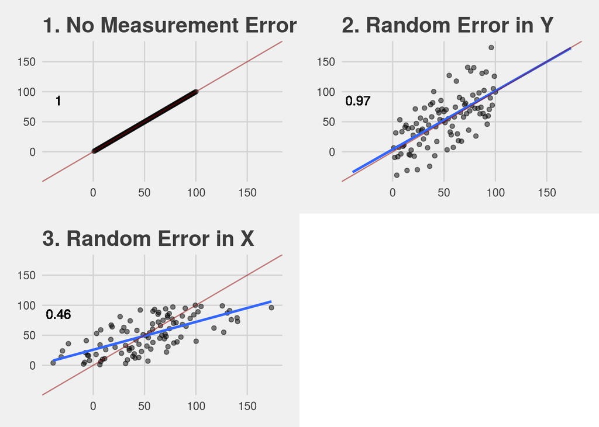

In Plot 2, where only the dependent variable is measured with error, we see that the points are much messier than in Plot 1. However, when we look at the regression coefficient, we still see a value reasonably close to 1, our true value. Remember that the red line represents the true best fit line. While the points in Plot 2 are scattered further away from the red line, they still do a decent job of blanketing the original red line; points are relatively spread evenly above and below the original line. The cost of the vertical spreading away from the true line is increased standard errors, but as we can see, when random measurement error affects only the dependent variable, the threat of bias is minimal.

Plot 3, which depicts a model which uses the independent variable measured with error, is a different story. Instead of vertical spreading, which is what we see in Plot 2, Plot 3 has horizontal smearing. This has functioned to flatten out the regression line. Looking at the points in Plot 3, you can see that the red line no longer best approximates a fit of the data, as it’s much steeper than the data appear to be. This “flattening out” toward zero is more formally referred to as attenuation bias. An additional confirmation is the coefficient size, which we can see is roughly half the size of the true value of 1. When subjected to the same magnitude of error, measurement error in the independent variables clearly presents a larger threat of bias than measurement error to the dependent variable.

It is important to note that attenuation bias is bias that pushes the coefficient toward zero. In this case, where we have a positive true coefficient, the attenuation bias will be negative. However, if the true coefficient is negative, attenuation will result in positive bias, pushing the coefficient closer to 0.

# A mathematical treatment of random measurement error

The best way to think about random measurement error mathematically is to recall (1) the formula for a regression coefficient and (2) the rules for linear combination; FUN!

The formula for a slope is:

$$\beta_1 = \frac{\sum(x_i - \mu_x)(y_i - \mu_y)}{\sum(x_i - \mu_x)^2} = \frac{cov(x,y)}{var(x)}$$

The second part, where you can express $\beta_1 = \frac{cov(x,y)}{var(x)}$ is most useful for understanding attenuation. Remember that we can express measurement error additively as:

$$x = x_t + \epsilon$$

where $x_t$, again, is the true x and $\epsilon$ is random error (i.e., uncorrelated with either x or y) and has a mean of 0 and some constant variance. So let’s sub in $x_t + \epsilon$ for all instances of x in the slope formula

$$\beta_1 = \frac{cov(x_t + \epsilon,y)}{var(x_t + \epsilon)}$$

**KEY TO ALL THIS: What measurement error in x does is make the denominator of the slope formula larger while leaving the numerator unchanged. This results in a smaller, i.e., attenuated, estimate of the slope.**

To figure why this is exactly, we need to use…rules of linear combinations. In particular:

1. Means of Linear Combinations: $E(a+b) = E(a)+E(b)$
2. Variances of Linear Combinations, where $a$ and $b$ are independent: $Var(a+b) = Var(a)+Var(b)$
3. Covariances of Linear Combinations: $Cov(a+b, c) = Cov(a,c) + Cov(b,c)$

The thing to keep in mind while going through these calculations is to see whether the statistic you calculate for x measured with error ($x$) is any different than the statistic you would have calculated if you had the true measure of x ($x_t$). So first, just for fun, what’s the mean of $x = x_t + \epsilon$?

$$E(x) = E(x_t + \epsilon) = E(x_t) + E(\epsilon) = E(x_t) + 0 = E(x_t)$$

Because $\epsilon$ has mean 0, the expected value of x measured with error is the same as the true x. Easy peasy, could have figured that out without the math. Now, how about with variances (the denominator of our slope formula)?

$$Var(x) = Var(x_t + \epsilon) = Var(x_t) + Var(\epsilon)$$

Because $\epsilon$ is random measurement error, $x_t$ and $\epsilon$ are independent and we can use the rule for variances of linear combinations above. Here, the variance of $x_t$, which would just be, duh, $var(x_t)$ is different than the variance of $x$, which is $Var(x_t) + Var(\epsilon)$. The variance of $x$, measured with error, will be larger than the variance of the true $x_t$

Lastly, how about the covariances (the numerator of our slope formula)? Using our rule of covariances of linear combinations above:

$$Cov(x,y) = Cov(x_t+\epsilon, y) = Cov(x_t,y) + Cov(\epsilon,y) = Cov(x_t,y) + 0 = Cov(x_t,y)$$

The covariance of x measured with error and y is therefore the same as the covariance of the true x and y. This is the case because the term $Cov(\epsilon,y)$ is equal to 0; remember, we are dealing with RANDOM measurement error and therefore it will not be correlated to any variables, making its covariances with other variables also 0.

Let’s put this together and see what it all means to our coefficient:

$$\beta_1 = \frac{cov(x_t + \epsilon,y)}{var(x_t + \epsilon)} = \frac{cov(x_t,y)}{var(x_t + \epsilon)}$$

Remember, consider how $\beta_1$ looks different from if we were to simply estimate it with the true $x$ to see the effect of measurement error. From above, we just showed that the numerator of the slope equation, the covariance of x and y, is unchanged from if we were to use the true x. **However** and this is the key to all of this, the denominator of the slope equation, the variance of x, is changed and is now larger than the variance of the true X since we now have the variance of the measurement error to deal with ($Var(x_t) + Var(\epsilon)$).

Therefore, when we have measurement error in X, it makes the denominator LARGER while leaving the numerator unchanged. This makes the value of $\beta_1$ smaller than it would have been had we used the true measure of X. This is the attenuation bias.

To see why introduction of measurement error to y does not introduce bias, we simply sub in $y_t + \epsilon$ for y in the slope formula.

$$\beta_1 = \frac{cov(x,y_t + \epsilon)}{var(x)}$$

Since y is only in the numerator, we only have to deal with the covariance calculation:

$$Cov(x,y) = Cov(x,y_t + \epsilon) = Cov(x,y_t) + Cov(x,\epsilon) = Cov(x,y_t) + 0 = Cov(x,y_t)$$

Much like for measurement error for x, the covariance between x and y measured with error is no different than the covariance of x and true y. Because y is not in the denominator, nothing about the calculation of $\beta_1$ is changed from if we were to use a true measure of y. Measurement error in y does lead to increased standard errors (which I don’t explain here), but again, does not lead to bias in the coefficients on x.